# main

## Loan Repayment Challenge

### Objective

Predict the loan risk or loan quality (loan repayment)

#### 1. Data Preparation

```python
from collections import Counter
import numpy as np
import pandas as pd

pd.pandas.set_option('display.max_columns', None)

import matplotlib.pyplot as plt
import seaborn as sns

%matplotlib inline
```

```python
# Preprocessing
from sklearn.preprocessing import LabelEncoder, StandardScaler

# Feature Selection
from sklearn.feature_selection import mutual_info_classif, VarianceThreshold

# Data Sampling & Splitting
from sklearn.model_selection import train_test_split
from imblearn.over_sampling import SMOTE
from imblearn.under_sampling import RandomUnderSampler
from imblearn.pipeline import Pipeline

# Modelling
from sklearn.linear_model import LogisticRegression
from sklearn.tree import DecisionTreeClassifier
import tensorflow as tf

# Evaluation Metrics
from sklearn.metrics import confusion_matrix
from utils import make_confusion_matrix, plot_metrics

# Model Export
import joblib
```

```python
loan_df = pd.read_csv(
    "./data/loan.csv", parse_dates=["applicationDate", "originatedDate"])
payment_df = pd.read_csv("./data/payment.csv", parse_dates=["paymentDate"])
clarity_df = pd.read_csv(
    "./data/clarity_underwriting_variables.csv", low_memory=False)
```

```python
payment_df["temp"] = 1
payment_status_pivot_table = pd.pivot_table(payment_df, index="loanId", columns="paymentStatus",
                            values="temp", aggfunc="sum", fill_value=0).reset_index()
```

```python
data = loan_df.merge(payment_status_pivot_table, on='loanId',
                        how='left')

data = data.merge(clarity_df,left_on='clarityFraudId', right_on='underwritingid', how='left')
```

```python
data.shape
```

```
(577682, 82)
```

#### 2. Data Analysis

2.1 Check if funded or non-funded loan is taken into account of the loan risk?

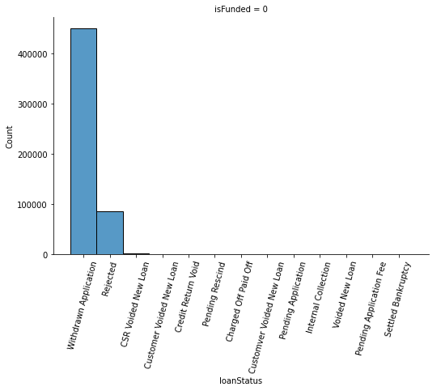

```python
non_funded_loan = data[data["isFunded"].eq(0)]

g = sns.FacetGrid(non_funded_loan, col="isFunded", height=5, aspect=1.5)
g.map(sns.histplot, "loanStatus")
g.add_legend()
g.set_xticklabels(rotation=75)
plt.show()
```

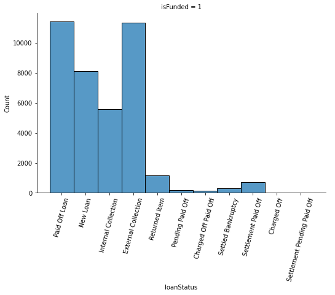

```python
funded_loan = data[data["isFunded"].eq(1)]

g = sns.FacetGrid(funded_loan, col="isFunded", height=5, aspect=1.5)
g.map(sns.histplot, "loanStatus")
g.add_legend()
g.set_xticklabels(rotation=75)
plt.show()
```

The loan application is withdrawn due to many vague reasons and it may not impact directly to the loan risk itself, so that's no point getting this large set of withdrawn loan and fit into the model. So we're going to drop the non-funded loan and we will only retained the funded loan in this case.

```python
# data = data.loc[data["isFunded"].eq(1) | (data["isFunded"].eq(0) & data["loanStatus"] == "Rejected")]
data = data.loc[data["isFunded"].eq(1)]
data.shape
```

```
(38982, 82)
```

2.2 Visualize the numeric continuous features distribution

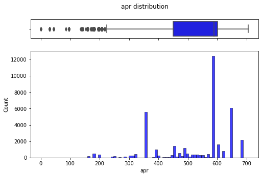

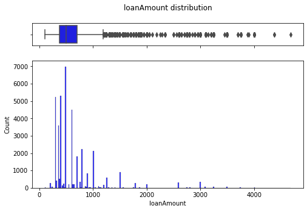

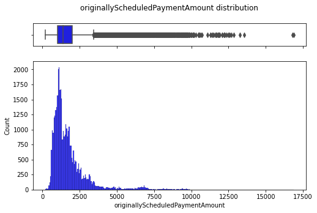

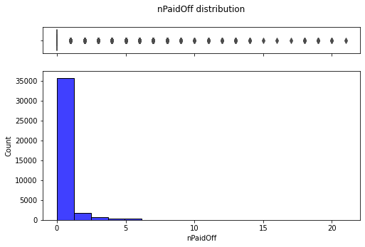

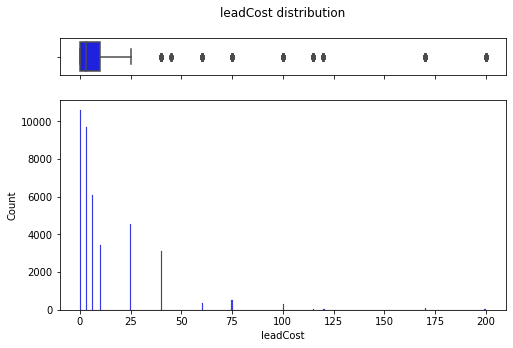

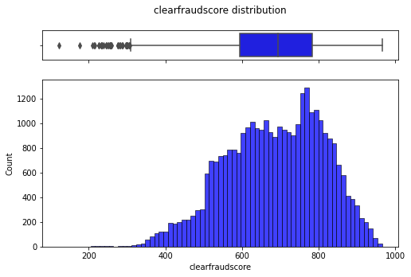

```python
features = ["apr", "loanAmount", "originallyScheduledPaymentAmount", "nPaidOff", "leadCost", "clearfraudscore"]

for feature in features:
    fig, (ax_box, ax_hist) = plt.subplots(2, sharex=True,
                                          gridspec_kw={"height_ratios": (.15, .85)}, figsize=(8, 5))
    sns.boxplot(x=data[feature], ax=ax_box, color='b')
    sns.histplot(data=data, x=feature, color='b')
    ax_box.set(xlabel='')
    ax_box.set_title(f"{feature} distribution\n")
    plt.show()
```

Seems like the numeric continuous features are skewed, we will need to normalize the data. Depending on which modelling approach we would like to use, tree based model is robust to skewness and outliers.

#### 3. Feature Engineering

In this step, we will perform and handle labelling, missing values, encoding and feature transformation.

3.1 Identify Label/Target Feature (y)

In this case, we will use `loanStatus` as our target feature, y.

```python
data["loanStatus"].value_counts(normalize=True).sort_values(ascending=False)
```

```
Paid Off Loan                  0.293135
External Collection            0.290750
New Loan                       0.208096
Internal Collection            0.142733
Returned Item                  0.030322
Settlement Paid Off            0.018162
Settled Bankruptcy             0.008337
Pending Paid Off               0.004335
Charged Off Paid Off           0.004079
Charged Off                    0.000026
Settlement Pending Paid Off    0.000026
Name: loanStatus, dtype: float64
```

To define a loan as risky or non-risky, we simply consider that:

| Loan Risk | Class | Characteristics | Loan Status Types |
| --- | --- | --- | --- |
| non-risky | 0 | the loan is being paid off | `Settlement Paid Off`, `Paid Off Loan` |
| risky | 1 | the loan is being defaulted, charged off, rejected or in the status of bankruptcy | `Charged Off`, `Settled Bankruptcy`, `Rejected` |

```python
category = {
    "Settlement Paid Off": 0,
    "Paid Off Loan": 0,
    "Charged Off": 1,
    "Settled Bankruptcy": 1,
    # "Rejected": 1,
}

data["risk"] = data["loanStatus"].map(category)
data.dropna(subset=["risk"], how="all", inplace=True)
data["risk"] = data["risk"].astype(int)
```

```python
data.shape
```

```
(12461, 83)
```

```python
loan_risk = data["risk"].value_counts(normalize=True).sort_index()
print(
    f"{loan_risk[0]*100:.2f}% non-risky loan, {loan_risk[1]*100:.2f}% risky loan")
```

```
97.38% non-risky loan, 2.62% risky loan
```

This is an imbalanced dataset, where there's a huge difference between risky loan and non-risky loan class. There are several ways to mitigate the model biases towards the majority class, but in this case, we will use F1-Score as our model performance metrics because for accuracy performance metrics might just predict 97.38% of the non-risky loan class but the risky loan might all get wrong.

3.2 Handling Missing Values

```python
# Print all nan features
features_with_na = [
    features for features in data.columns if data[features].isnull().sum() > 1]

for feature in features_with_na:
    print("{:<100} {:<5} % missing values".format(feature, np.round(data[feature].isnull().mean(), 4)))
```

```
nPaidOff                                                                                             0.0006 % missing values
clarityFraudId                                                                                       0.2041 % missing values
Cancelled                                                                                            0.0002 % missing values
Checked                                                                                              0.0002 % missing values
Complete                                                                                             0.0002 % missing values
None                                                                                                 0.0002 % missing values
Pending                                                                                              0.0002 % missing values
Rejected                                                                                             0.0002 % missing values
Rejected Awaiting Retry                                                                              0.0002 % missing values
Returned                                                                                             0.0002 % missing values
Skipped                                                                                              0.0002 % missing values
.underwritingdataclarity.clearfraud.clearfraudinquiry.thirtydaysago                                  0.205 % missing values
.underwritingdataclarity.clearfraud.clearfraudinquiry.twentyfourhoursago                             0.205 % missing values
.underwritingdataclarity.clearfraud.clearfraudinquiry.oneminuteago                                   0.205 % missing values
.underwritingdataclarity.clearfraud.clearfraudinquiry.onehourago                                     0.205 % missing values
.underwritingdataclarity.clearfraud.clearfraudinquiry.ninetydaysago                                  0.205 % missing values
.underwritingdataclarity.clearfraud.clearfraudinquiry.sevendaysago                                   0.205 % missing values
.underwritingdataclarity.clearfraud.clearfraudinquiry.tenminutesago                                  0.205 % missing values
.underwritingdataclarity.clearfraud.clearfraudinquiry.fifteendaysago                                 0.205 % missing values
.underwritingdataclarity.clearfraud.clearfraudinquiry.threesixtyfivedaysago                          0.205 % missing values
.underwritingdataclarity.clearfraud.clearfraudindicator.inquiryonfilecurrentaddressconflict          0.2062 % missing values
.underwritingdataclarity.clearfraud.clearfraudindicator.totalnumberoffraudindicators                 0.2055 % missing values
.underwritingdataclarity.clearfraud.clearfraudindicator.telephonenumberinconsistentwithaddress       0.2062 % missing values
.underwritingdataclarity.clearfraud.clearfraudindicator.inquiryageyoungerthanssnissuedate            0.2062 % missing values
.underwritingdataclarity.clearfraud.clearfraudindicator.onfileaddresscautious                        0.2062 % missing values
.underwritingdataclarity.clearfraud.clearfraudindicator.inquiryaddressnonresidential                 0.2062 % missing values
.underwritingdataclarity.clearfraud.clearfraudindicator.onfileaddresshighrisk                        0.2062 % missing values
.underwritingdataclarity.clearfraud.clearfraudindicator.ssnreportedmorefrequentlyforanother          0.2062 % missing values
.underwritingdataclarity.clearfraud.clearfraudindicator.currentaddressreportedbytradeopenlt90days    0.2062 % missing values
.underwritingdataclarity.clearfraud.clearfraudindicator.inputssninvalid                              0.2062 % missing values
.underwritingdataclarity.clearfraud.clearfraudindicator.inputssnissuedatecannotbeverified            0.2062 % missing values
.underwritingdataclarity.clearfraud.clearfraudindicator.inquiryaddresscautious                       0.2062 % missing values
.underwritingdataclarity.clearfraud.clearfraudindicator.morethan3inquiriesinthelast30days            0.2062 % missing values
.underwritingdataclarity.clearfraud.clearfraudindicator.onfileaddressnonresidential                  0.2062 % missing values
.underwritingdataclarity.clearfraud.clearfraudindicator.creditestablishedpriortossnissuedate         0.2062 % missing values
.underwritingdataclarity.clearfraud.clearfraudindicator.driverlicenseformatinvalid                   0.3236 % missing values
.underwritingdataclarity.clearfraud.clearfraudindicator.inputssnrecordedasdeceased                   0.2062 % missing values
.underwritingdataclarity.clearfraud.clearfraudindicator.inquiryaddresshighrisk                       0.2062 % missing values
.underwritingdataclarity.clearfraud.clearfraudindicator.inquirycurrentaddressnotonfile               0.2062 % missing values
.underwritingdataclarity.clearfraud.clearfraudindicator.bestonfilessnissuedatecannotbeverified       0.2062 % missing values
```

[output cut: 10 more lines]

```
.underwritingdataclarity.clearfraud.clearfraudidentityverification.nameaddressmatch                  0.2058 % missing values
.underwritingdataclarity.clearfraud.clearfraudidentityverification.phonematchtype                    0.2196 % missing values
.underwritingdataclarity.clearfraud.clearfraudidentityverification.ssnnamereasoncodedescription      0.9582 % missing values
.underwritingdataclarity.clearfraud.clearfraudidentityverification.phonematchresult                  0.2062 % missing values
.underwritingdataclarity.clearfraud.clearfraudidentityverification.nameaddressreasoncodedescription  0.9142 % missing values
.underwritingdataclarity.clearfraud.clearfraudidentityverification.phonematchtypedescription         0.2196 % missing values
.underwritingdataclarity.clearfraud.clearfraudidentityverification.overallmatchresult                0.2058 % missing values
.underwritingdataclarity.clearfraud.clearfraudidentityverification.phonetype                         0.9719 % missing values
.underwritingdataclarity.clearfraud.clearfraudidentityverification.ssndobreasoncode                  0.8446 % missing values
.underwritingdataclarity.clearfraud.clearfraudidentityverification.ssnnamereasoncode                 0.9582 % missing values
.underwritingdataclarity.clearfraud.clearfraudidentityverification.nameaddressreasoncode             0.9142 % missing values
.underwritingdataclarity.clearfraud.clearfraudidentityverification.ssndobmatch                       0.2058 % missing values
.underwritingdataclarity.clearfraud.clearfraudidentityverification.overallmatchreasoncode            0.2058 % missing values
clearfraudscore                                                                                      0.2074 % missing values
underwritingid                                                                                       0.205 % missing values
```

```python
# Remove all underwritingdataclarity categorical feature
column = [col for col in data.columns if ".underwritingdataclarity.clearfraud" not in col or (
    ".underwritingdataclarity.clearfraud" in col and data[col].dtypes != "O")]
data = data[column]
```

```python
# Drop id column
data.drop("clarityFraudId", axis=1, inplace=True)
data.drop("underwritingid", axis=1, inplace=True)
```

```python
# Drop column that are more than 50% missing values
data = data.loc[:, data.isnull().mean() < .5]
```

```python
# Fill bounding feature column with 0
features = ["nPaidOff", "Cancelled", "Checked", "Complete", "None", "Pending", "Rejected", "Rejected Awaiting Retry", "Returned", "Skipped"]

for feature in features:
    data[feature].fillna(0, inplace=True)
```

```python
# Fill the numerical continuous variable with its mean/median
features_with_na = [
    features for features in data.columns if data[features].isnull().sum() > 1]

numeric_features = [num for num in data.columns if data[num].dtypes !=
                "O" and num in features_with_na]

for col in numeric_features:
    data[col].fillna(data[col].median(), inplace=True)
```

```python
# Check if there's any missing values and infinity values in the data
# np.any(np.isnan(data)), np.any(np.isfinite(data))
```

3.3 Handling Date Features

There's a loan processing period that might be a useful features for the model, because if the loan process time is long, the loan might be risky.

```python
data["loanProcessTime"] = (data["originatedDate"] -
                           data["applicationDate"]).astype('timedelta64[h]').astype(int)
```

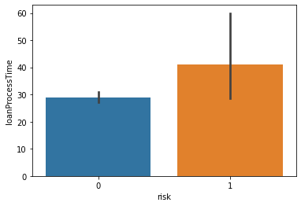

```python
sns.barplot(data=data, x="risk", y="loanProcessTime")
plt.show()
```

The loans that are risky took average more time to process compared to the loans that are not risky. We can also extract the loan originated date/day/hour and loan accepted date/day/hour.

```python
data["originWeekday"] = data["originatedDate"].dt.weekday  # 0 - 6
data["originDay"] = data["originatedDate"].dt.day  # 1 - 31
data["originHour"] = data["originatedDate"].dt.hour  # 0 - 23

data["acceptedWeekday"] = data["applicationDate"].dt.weekday
data["acceptedDay"] = data["applicationDate"].dt.day
data["acceptedHour"] = data["applicationDate"].dt.hour
```

Check the loan origin datetime and accepted datetime pattern corresponds to the loan risk

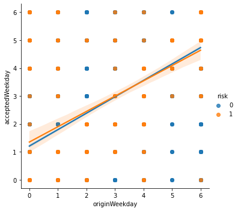

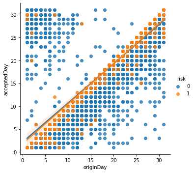

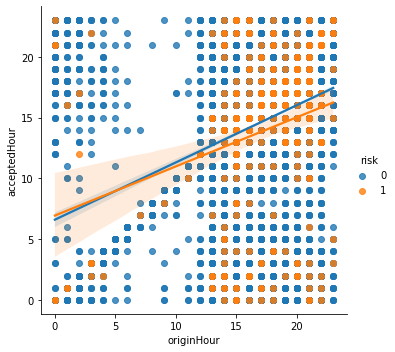

```python
plt.figure(figsize=(10, 6))
sns.lmplot(x="originWeekday", y="acceptedWeekday",
            data=data, hue="risk")
sns.lmplot(x="originDay", y="acceptedDay", data=data, hue="risk")
sns.lmplot(x="originHour", y="acceptedHour",
            data=data, hue="risk")
plt.show()
```

Through these plot, we can see that:

1. The loans that are originated at Monday and Friday are at high risk (First Plot)
2. The loans that are accepted at Saturday are at high risk (First Plot)
3. The loans that are originated and accepted under the same day are at high risk (Second Plot)
4. The loans that are originated and accepted at night are mostly at high risk (Third Plot)

3.4 Handling Group Features

Add more features based on the client's ssn by grouping several features:

1. Number of loan they have
2. Number of paid off times

```python
anon_ssn_duplicate_count = (data.pivot_table(columns=['anon_ssn'], aggfunc='size') > 1).sum()
print(f"There are {anon_ssn_duplicate_count} clients that apply for 2 or more loans")
```

```
There are 1723 clients that apply for 2 or more loans
```

```python
data["loanCountPerClient"] = data["anon_ssn"].map(data.groupby("anon_ssn")["loanId"].count()).astype(int)
data["paidOffCountPerClient"] = data["anon_ssn"].map(
    data.groupby("anon_ssn")["nPaidOff"].sum()).astype(int)
```

3.5 Handling Categorical Features

Ordinal Feature

- `payFrequency`

Nominal Feature

- `state`
- `leadType`
- `fpStatus`
- `originated`
- `approved`

```python
# Rank pay frequency from lower to higher
pay_frequency_category = {
    "I": 0,
    "M": 1,
    "B": 2,
    "S": 3,
    "W": 4,
}

data["payFrequency"] = data["payFrequency"].map(pay_frequency_category).astype(int)
```

```python
nominal_features = ["state", "leadType", "fpStatus", "originated", "approved"]

for feature in nominal_features:
    encoder = LabelEncoder()
    data[feature + '_en'] = encoder.fit_transform(data[feature])
```

3.6 Drop Unwanted Columns

```python
unwanted_features = nominal_features + ["loanId", "anon_ssn", "applicationDate", "originatedDate", "isFunded", "loanStatus"]

data.drop(unwanted_features, axis=1, inplace=True)
```

3.8 Handling Feature Transformation

This section will be performed later at the modelling experiment.

#### 4. Feature Selection

4.1 Handling Constant Features

We will drop the constant features using variance threshold technique because there's no point using the features that are highly similar(or constant).

```python
var_thres = VarianceThreshold(threshold=0)
var_thres.fit(data)  # x features pd dataframe

var_thres.get_support()

constant_columns = [
    column for column in data.columns if column not in data.columns[var_thres.get_support()]]

constant_columns
```

```
['Returned', 'originated_en', 'approved_en']
```

```python
data.drop(constant_columns, axis=1, inplace=True)
```

4.2 Handling Highly Correlated Features

We will drop the highly correlated features using pearson correlation technique because there's no point using two features that are almost related.

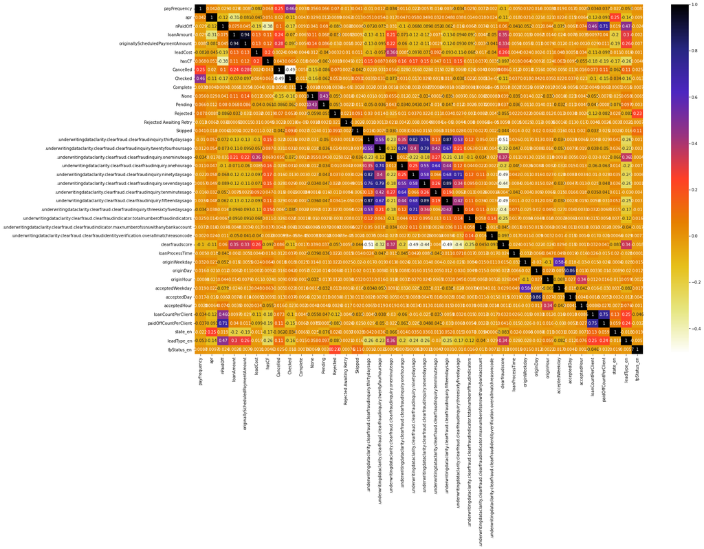

```python
features = data.drop("risk", axis=1)

# Visualize features correlation
plt.figure(figsize=(25, 16))
cor = features.corr()
sns.heatmap(cor, annot=True, cmap=plt.cm.CMRmap_r)
plt.show()
```

```python
# get highly correlated columns
def correlation(dataset, threshold=0.95):
	col_corr = set()
	corr_matrix = dataset.corr()
	for i in range(len(corr_matrix.columns)):
		for j in range(i):
			if abs(corr_matrix.iloc[i, j]) > threshold:
				colname = corr_matrix.columns[i]
				col_corr.add(colname)
	return col_corr


high_corr_columns = correlation(features, 0.95)
high_corr_columns
```

```
set()
```

```python
data.drop(high_corr_columns, axis=1, inplace=True)
```

4.3 Ranking Features Importance Using Information Gain

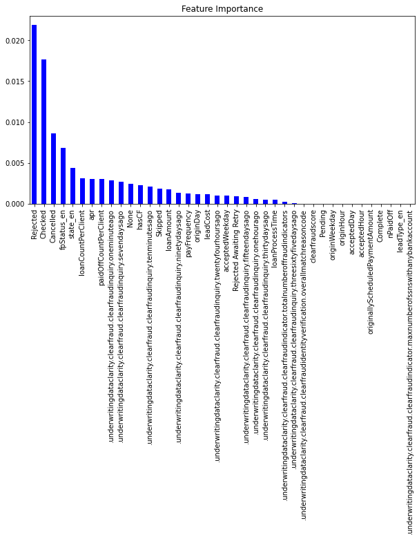

```python
features = data.drop("risk", axis=1)

mutual_info = mutual_info_classif(features, data["risk"])
mutual_info = pd.Series(mutual_info)
mutual_info.index = features.columns
plt.figure(figsize=(10, 5))
mutual_info.sort_values(ascending=False).plot.bar(color="b")
plt.title("Feature Importance")
plt.xticks(rotation=90)
plt.show()
```

#### 5. Data Preparation

In this section, we will create two dataset:

1. Normal data - `X_train, X_valid, y_train, y_valid`
2. SMOTE and undersampling data - `X_train_balanced, X_valid_balanced, y_train_balanced, y_valid_balanced`

Since our dataset is unbalanced, we will compare two types of datasets above on each model

5.1 Normal Data Splitting

```python
target = data['risk']
X_train, X_valid, y_train, y_valid = train_test_split(
    data, target, test_size=0.2, stratify=target, random_state=99)

X_train = X_train.drop(['risk'], axis=1)
X_valid = X_valid.drop(['risk'], axis=1)
```

```python
X_train.shape, y_train.shape, X_valid.shape, y_valid.shape
```

```
((9968, 40), (9968,), (2493, 40), (2493,))
```

```python
(neg_train, pos_train), (neg_valid, pos_valid) = np.bincount(
    y_train), np.bincount(y_valid)

print(f"There are {neg_train} negative class in training set")
print(f"There are {pos_train} positive class in training set")
print(f"There are {neg_valid} negative class in validation set")
print(f"There are {pos_valid} positive class in validation set")
```

```
There are 9707 negative class in training set
There are 261 positive class in training set
There are 2428 negative class in validation set
There are 65 positive class in validation set
```

5.2 SMOTE and Undersampling Data Splitting (Data Class Balancing)

```python
over = SMOTE(sampling_strategy=0.1, random_state=42)
under = RandomUnderSampler(sampling_strategy=0.5, random_state=42)
steps = [('o', over), ('u', under)]
pipeline = Pipeline(steps=steps)
```

```python
X, y = pipeline.fit_resample(data.drop("risk", axis=1), data["risk"])
X.shape, y.shape
```

```
((3639, 40), (3639,))
```

```python
X_train_balanced, X_valid_balanced, y_train_balanced, y_valid_balanced = train_test_split(
    X, y, test_size=0.2, random_state=99)
X_train_balanced.shape, X_valid_balanced.shape, y_train_balanced.shape, y_valid_balanced.shape
```

```
((2911, 40), (728, 40), (2911,), (728,))
```

```python
(neg_train, pos_train), (neg_valid, pos_valid) = np.bincount(
    y_train_balanced), np.bincount(y_valid_balanced)

print(f"There are {neg_train} negative class in training set")
print(f"There are {pos_train} positive class in training set")
print(f"There are {neg_valid} negative class in validation set")
print(f"There are {pos_valid} positive class in validation set")
```

```
There are 1948 negative class in training set
There are 963 positive class in training set
There are 478 negative class in validation set
There are 250 positive class in validation set
```

5.3 Data Normalization

5.3.1 Data Normalization for normal datasets

```python
normal_scaler = StandardScaler()

train_features = normal_scaler.fit_transform(X_train)
val_features = normal_scaler.transform(X_valid)

X_train_norm = np.clip(train_features, -5, 5)
X_valid_norm = np.clip(val_features, -5, 5)


print('Training labels shape:', y_train.shape)
print('Validation labels shape:', y_valid.shape)

print('Training features shape:', train_features.shape)
print('Validation features shape:', val_features.shape)
```

```
Training labels shape: (9968,)
Validation labels shape: (2493,)
Training features shape: (9968, 40)
Validation features shape: (2493, 40)
```

5.3.2 Data Normalization for balanced datasets

```python
balance_scaler = StandardScaler()

train_features = balance_scaler.fit_transform(X_train_balanced)
val_features = balance_scaler.transform(X_valid_balanced)

X_train_balanced = np.clip(train_features, -5, 5)
X_valid_balanced = np.clip(val_features, -5, 5)


print('Training labels shape:', y_train_balanced.shape)
print('Validation labels shape:', y_valid_balanced.shape)

print('Training features shape:', train_features.shape)
print('Validation features shape:', val_features.shape)
```

```
Training labels shape: (2911,)
Validation labels shape: (728,)
Training features shape: (2911, 40)
Validation features shape: (728, 40)
```

5.4 Data Loading into Tensors

```python
# Load normalized data into prefetched batch dataset
train_dataset_normal = tf.data.Dataset.from_tensor_slices(
    (X_train_norm, y_train)).prefetch(tf.data.AUTOTUNE).batch(128)
valid_dataset_normal = tf.data.Dataset.from_tensor_slices(
    (X_valid_norm, y_valid)).prefetch(tf.data.AUTOTUNE).batch(128)
```

```python
# Load normalized and balanced data into prefetched batch dataset
train_dataset_balanced = tf.data.Dataset.from_tensor_slices(
    (X_train_balanced, y_train_balanced)).prefetch(tf.data.AUTOTUNE).batch(128)
valid_dataset_balanced = tf.data.Dataset.from_tensor_slices(
    (X_valid_balanced, y_valid_balanced)).prefetch(tf.data.AUTOTUNE).batch(128)
```

5.5 Model Evaluation Metrics

5.5.1 Confusion Matrix

```python
labels = ['True Negative', 'False Positive', 'False Negative', 'True Positive']
categories = ['0', '1']
```

5.5.2 TensorFlow model metrics

```python
METRICS = [
    tf.keras.metrics.TruePositives(name='tp'),
    tf.keras.metrics.FalsePositives(name='fp'),
    tf.keras.metrics.TrueNegatives(name='tn'),
    tf.keras.metrics.FalseNegatives(name='fn'),
    tf.keras.metrics.BinaryAccuracy(name='accuracy'),
    tf.keras.metrics.Precision(name='precision'),
    tf.keras.metrics.Recall(name='recall'),
    tf.keras.metrics.AUC(name='auc'),
    tf.keras.metrics.AUC(name='prc', curve='PR'),  # precision-recall curve
]
```

5.6 Model Experiment

We will use f1 score as our performance evaluation metrics mainly for imbalanced dataset.

We will compare the two datasets(balanced/imbalanced) above in this model experiment using 3 types of algorithm/model:

5.6.1 Logistic Regression

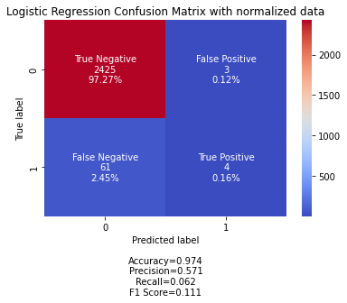

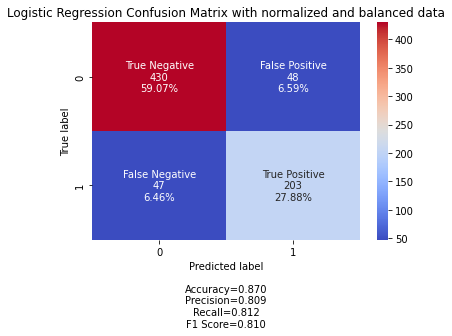

```python
# Normalized but unbalanced data
lr_clf_1 = LogisticRegression(random_state=42, max_iter=1000)
lr_clf_1.fit(X_train_norm, y_train)
y_pred = lr_clf_1.predict(X_valid_norm)

make_confusion_matrix(
    confusion_matrix(y_valid, y_pred),
    group_names=labels,
    categories=categories,
    cmap='coolwarm',
    title="Logistic Regression Confusion Matrix with normalized data"
)

# Normalized and balanced data
lr_clf_2 = LogisticRegression(random_state=42, max_iter=1000)
lr_clf_2.fit(X_train_balanced, y_train_balanced)
y_pred = lr_clf_2.predict(X_valid_balanced)

make_confusion_matrix(
    confusion_matrix(y_valid_balanced, y_pred),
    group_names=labels,
    categories=categories,
    cmap='coolwarm',
    title="Logistic Regression Confusion Matrix with normalized and balanced data"
)
```

Although the plot above (imbalanced data) shows higher accuracy compared to the plot below (balanced data), it might not able to make proper prediction when it comes to predicting risky loan (class 1).

5.6.2 Decision Tree

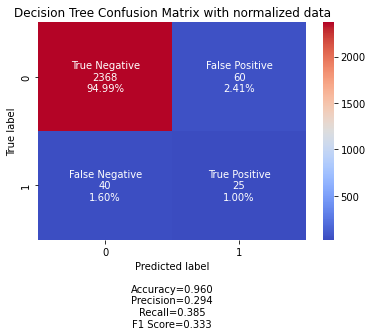

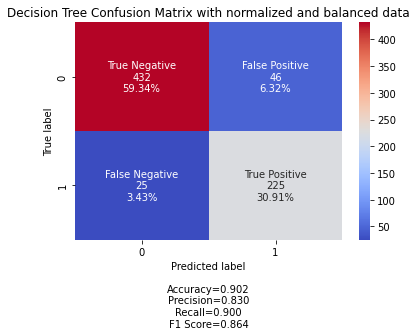

```python
# Normalized but unbalanced data
dt_clf_1 = DecisionTreeClassifier()
dt_clf_1.fit(X_train_norm, y_train)
y_pred = dt_clf_1.predict(X_valid_norm)

make_confusion_matrix(
    confusion_matrix(y_valid, y_pred),
    group_names=labels,
    categories=categories,
    cmap='coolwarm',
    title="Decision Tree Confusion Matrix with normalized data"
)

# Normalized and balanced data
dt_clf_2 = DecisionTreeClassifier()
dt_clf_2.fit(X_train_balanced, y_train_balanced)
y_pred = dt_clf_2.predict(X_valid_balanced)

make_confusion_matrix(
    confusion_matrix(y_valid_balanced, y_pred),
    group_names=labels,
    categories=categories,
    cmap='coolwarm',
    title="Decision Tree Confusion Matrix with normalized and balanced data"
)
```

Obviously, decision tree is robust to imbalanced data, it's f1 score is greater compared to logistics regression, it perform better of course with balanced data.

5.6.3 Neural Network with imbalanced data

```python
early_stopping = tf.keras.callbacks.EarlyStopping(
    monitor='val_prc', patience=10, restore_best_weights=True, mode="max"),
```

```python
neg, pos = np.bincount(data["risk"])
total = neg + pos
neg, pos, total
```

```
(12135, 326, 12461)
```

```python
initial_bias = np.log([pos/neg])
initial_bias
```

```
array([-3.61695174])
```

```python
def model():
    input = tf.keras.layers.Input(shape=(train_features.shape[-1]))
    x = tf.keras.layers.Dense(16, activation="relu")(input)
    x = tf.keras.layers.Dense(4, activation="relu")(x)
    x = tf.keras.layers.Dense(2, activation="relu")(x)
    x = tf.keras.layers.Dropout(0.5)(x)
    output = tf.keras.layers.Dense(1, activation="sigmoid")(x)

    model = tf.keras.Model(input, output)

    model.compile(
        loss=tf.keras.losses.BinaryCrossentropy(),
        optimizer=tf.keras.optimizers.Adam(learning_rate=0.01),
        metrics=METRICS
    )
    return model

def predict(model, X):
    y_pred = model.predict(X).squeeze()
    y_pred = tf.where(y_pred > 0.5, 1, 0)
    y_pred = y_pred.numpy()
    return y_pred
```

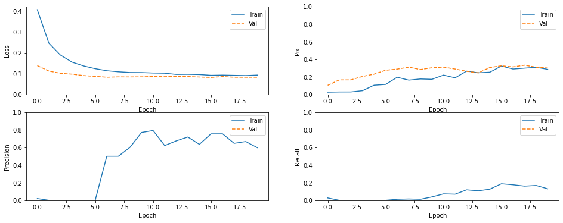

```python
baseline = model()

baseline_history = baseline.fit(
    train_dataset_normal,
    validation_data=valid_dataset_normal,
    epochs=20,
    callbacks=[
        early_stopping
    ],
    verbose=0
)

plt.figure(figsize=(16, 6))
plot_metrics(baseline_history)
```

```
d:\Interview\Moneylion DS Interview Questions\utils.py:70: RuntimeWarning: invalid value encountered in longlong_scalars
  precision = cf[1, 1] / sum(cf[:, 1])
```

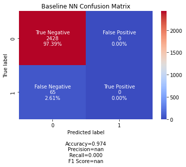

```python
y_pred = predict(baseline, X_valid_norm)
make_confusion_matrix(
    confusion_matrix(y_valid, y_pred),
    group_names=labels,
    categories=categories,
    cmap='coolwarm',
    title="Baseline NN Confusion Matrix"
)
```

The result is quite bad in this case, we will perform class weighting technique to cause the model pay more attention to examples from under-represented class

```python
baseline.save_weights("./initial_weights/")
```

```python
weight_for_0 = (1 / neg) * (total / 2.0)
weight_for_1 = (1 / pos) * (total / 2.0)

class_weight = {0: weight_for_0, 1: weight_for_1}

print('Weight for class 0: {:.2f}'.format(weight_for_0))
print('Weight for class 1: {:.2f}'.format(weight_for_1))
```

```
Weight for class 0: 0.51
Weight for class 1: 19.11
```

```python
weighted_model = model()
weighted_model.load_weights("./initial_weights/")

weighted_history = weighted_model.fit(
    train_dataset_normal,
    epochs=100,
    callbacks=[early_stopping],
    validation_data=valid_dataset_normal,
    class_weight=class_weight
)
```

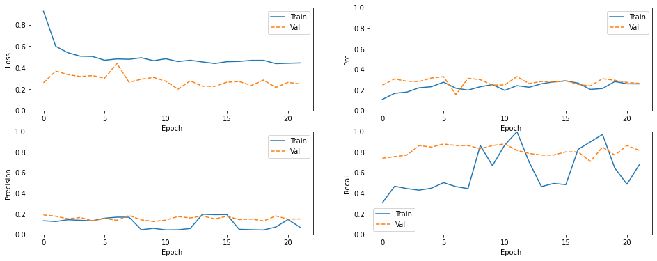

```python
plt.figure(figsize=(16, 6))
plot_metrics(weighted_history)
```

```python
y_pred = predict(weighted_model, X_valid_norm)
```

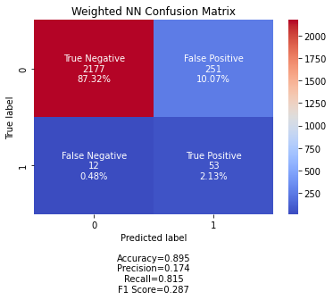

```python
make_confusion_matrix(
    confusion_matrix(y_valid, y_pred),
    group_names=labels,
    categories=categories,
    cmap='coolwarm',
    title="Weighted NN Confusion Matrix"
)
```

The result is also not very good, but is better than the fitting of data without class weighting, so we will implement the neural network with balanced dataset.

5.6.4 Neural Network with balanced data

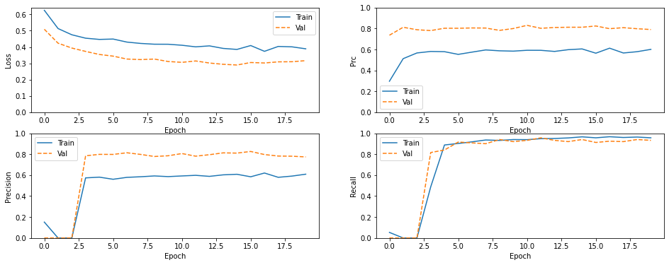

```python
nn = model()

nn_history = nn.fit(
    train_dataset_balanced,
    validation_data=valid_dataset_balanced,
    epochs=20,
    callbacks=[
        early_stopping
    ],
    verbose=0
)

plt.figure(figsize=(16, 6))
plot_metrics(nn_history)
```

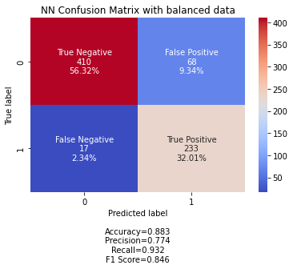

```python
y_pred = predict(nn, X_valid_balanced)
make_confusion_matrix(
    confusion_matrix(y_valid_balanced, y_pred),
    group_names=labels,
    categories=categories,
    cmap='coolwarm',
    title="NN Confusion Matrix with balanced data"
)
```

Hmm... This really improve a lot as compared to class weighting technique in the previous neural network implementation.

#### Model Export

```python
!mkdir "model"
```

```python
sklearn_model = [lr_clf_1, lr_clf_2, dt_clf_1, dt_clf_2]

for i, m in enumerate(sklearn_model):
    joblib.dump(m, f'./model/model_{i}.joblib')

tf_model = [weighted_model, nn]

for i, m in enumerate(tf_model):
    m.save(f"./model/nn_{i}.h5")
```

#### Conclusion

1. Only approximately 2.62% of risky loan that leads to imbalance dataset.
2. More data about risky loan need to be collected to ensure that the model created is able to predict properly in the real world situation.
3. There's still quite vague and difficult to determine the feature importance
4. More effort need to be done on feature understanding, feature engineering and feature selection to extract and introduce more features based on the context of finance.
5. More modelling experiment including hyperparameter tuning (e.g. GridSearchCV) need to be done.